# STA 101 - HW 4

Mingyi Xue

May 10, 2018

### Load datasets

```r
alcohol <- read.csv("~/STA 101/Homework/HW4/alcohol.csv")
CHD <- read.csv("~/STA 101/Homework/HW4/CHD.csv")
flu <- read.csv("~/STA 101/Homework/HW4/flu.csv")
```

### Install and import packages

```r
library(ggplot2)
library(pROC)
library(EnvStats)
```

### Problem 1

**(a)**

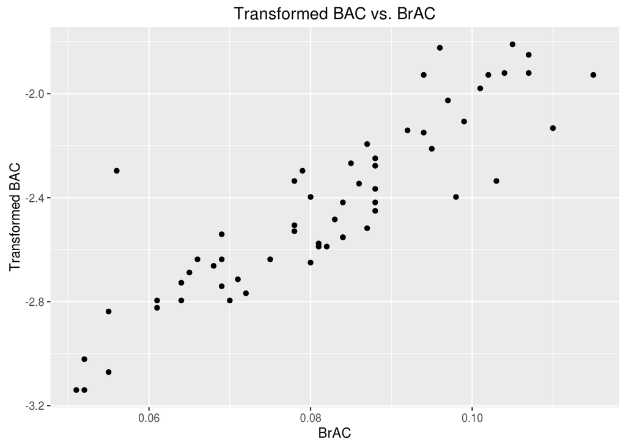

Method: Log-Likelihood.  
Value of $\lambda = -0.321$.

**(b)**

```
##
## Results of Hypothesis Test
## --------------------------
##
## Alternative Hypothesis:
##
## Test Name:                       Fligner-Killeen test of homogeneity of variances
##
## Data:                            t.data$ei and t.data$Group
##
## Test Statistic:                  Fligner-Killeen:med chi-squared = 1.627073
##
## Test Statistic Parameter:        df = 1
##
## P-value:                         0.2021083
```

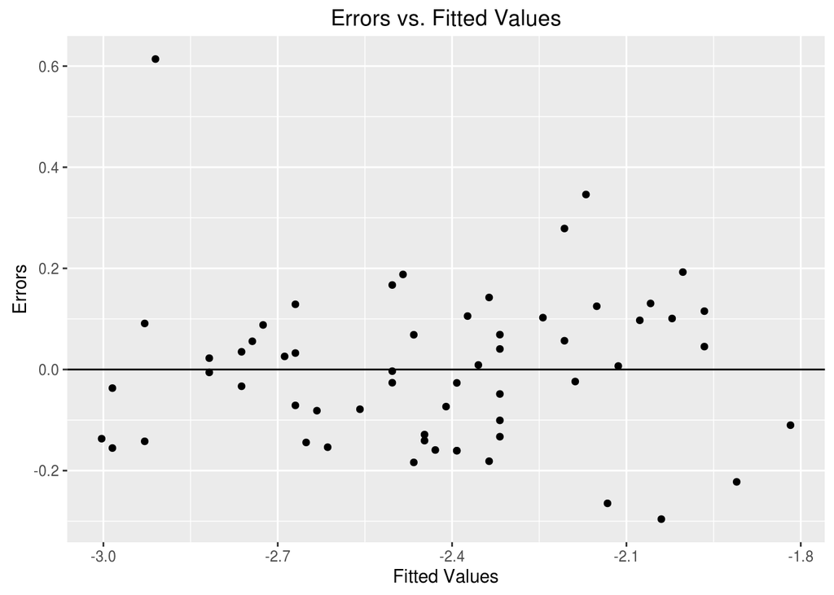

Hypothesis:  
$H_{0}:\sigma^{2}_{lower}=\sigma^{2}_{upper}$  
$H_{A}:\sigma^{2}_{lower}\neq\sigma^{2}_{upper}$  
Conclusion:  
P-value is $0.2021>\alpha=0.05$, fail to reject $H_{0}$ and conclude that the variance are the same in both upper and lower groups at $95\%$ significance.

**(c)**

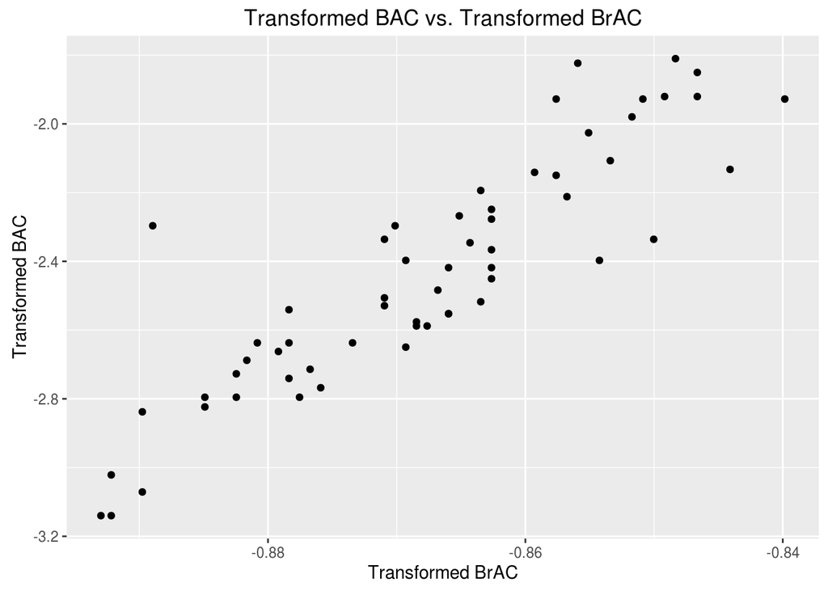

Method: Log-Likelihood.  
$\lambda$ for BAC is $-0.321$, $\lambda$ for BrAC is $1.074$.

**(d)**

```
##
## Results of Hypothesis Test
## --------------------------
##
## Alternative Hypothesis:
##
## Test Name:                       Shapiro-Wilk normality test
##
## Data:                            ei
##
## Test Statistic:                  W = 0.9388731
##
## P-value:                         0.005282791
```

```
##
## Results of Hypothesis Test
## --------------------------
##
## Alternative Hypothesis:
##
## Test Name:                       Fligner-Killeen test of homogeneity of variances
##
## Data:                            tt.data$ei and tt.data$Group
##
## Test Statistic:                  Fligner-Killeen:med chi-squared = 1.813311
##
## Test Statistic Parameter:        df = 1
##
## P-value:                         0.1781116
```

S-W test:  
Hypothesis:  
$H_{0}$:The data is normally distributed.  
$H_{A}$:The data is not normally distributed.  
Conclusion:  
P-value is $0.005283<\alpha=0.01$, reject $H_{0}$ and conclude that the data is not normally distributed.

F-K test:  
Hypothesis:  
$H_{0}:\sigma^{2}_{lower}=\sigma^{2}_{upper}$  
$H_{A}:\sigma^{2}_{lower}\neq\sigma^{2}_{upper}$  
Conclusion:  
P-value is $0.1781>\alpha=0.05$, fail to reject $H_{0}$ and conclude that the variance are the same in both upper and lower groups at $95\%$ significance.

**(e)**

Because p-value of F-K test for dataset with transformed BAC is 0.2021 and is larger than that for dataset with transformed BrAC and BAC, which is 0.1781, so I woud suggest transformation only for Y.

### Problem 2

**(a)**

```
## (Intercept)         age       aware     genderM
## -1.17715922  0.07278802 -0.09898649  0.43397485
```

```
## (Intercept)     exp.age   exp.aware exp.genderM
##   0.3081529   1.0755025   0.9057549   1.5433801
```

```
##                     5 %      95 %
## (Intercept) 0.002186928 41.925307
## exp.age     1.024262188  1.132685
## exp.aware   0.853833667  0.954015
## exp.genderM 0.660299443  3.728585
```

```
##
## Call:
## glm(formula = shot ~ age + aware + gender, family = binomial(link = logit),
##     data = flu)
##
## Deviance Residuals:
##     Min       1Q   Median       3Q      Max
## -1.4037  -0.5637  -0.3352  -0.1542   2.9394
##
## Coefficients:
##             Estimate Std. Error z value Pr(>|z|)
## (Intercept) -1.17716    2.98242  -0.395  0.69307
## age          0.07279    0.03038   2.396  0.01658 *
## aware       -0.09899    0.03348  -2.957  0.00311 **
## genderM      0.43397    0.52179   0.832  0.40558
## ---
## Signif. codes:  0 '***' 0.001 '**' 0.01 '*' 0.05 '.' 0.1 ' ' 1
##
## (Dispersion parameter for binomial family taken to be 1)
##
##     Null deviance: 134.94  on 158  degrees of freedom
## Residual deviance: 105.09  on 155  degrees of freedom
## AIC: 113.09
##
## Number of Fisher Scoring iterations: 6
```

The estimated logistic-regression function : $\ln \frac{\hat{\pi}}{1-\hat{\pi}} = -1.1772 + 0.0728X_{1} -0.099X_{2} + 0.434X_{M}$.

**(b)**

```
##          1
## 0.01625649
```

**(c)**

```
##        age
## 0.07278802
```

Since $\beta_{1} = 0.0728 > 0$, the probability of a flu shot goes up as your age increases.

**(d)**

```
##  exp.age
## 1.075503
```

Holding all other variables as constant, when age increases by 1 year, the odds of flu shot will be 1.0755 times that of what it was.

**(e)**

```
##      5 %     95 %
## 1.024262 1.132685
```

We are 90% confident that when age increases by 1 year, we expect the odds of flu shot to be between 1.0243 and 1.1327 times of what it was, holding all other variables constant.

**(f)**

```
## exp.genderM
##     1.54338
```

Holding all other variables as constant, the odds of flu shot for Male is 1.5434 times that for Female.

**(g)**

We are 90% confident that the odds of flu shot tends to ibe between 0.6603 and 3.7286 times what it was when a patient is Male compared to Female, holding all other variables constant.

### Problem 3

**(a)**

It is difficult to interpret $\beta$’s in logistic regression problem. $e^{\beta_{0}}$ represents the odds of a female patient who is 0 year old and has no awareness of health, $e^{\beta_{0}}$ doesn’t make sense in this case since a patient cannot be 0 year old.

**(b)**

The reasonable range for patients’ age is from 48 to 84. So it is inappropriate to predict someone aged 12.

**(c)**

```
## Sensitivity Specificity  Error Rate
##      0.2500      0.9630      0.1447
```

**(d)**

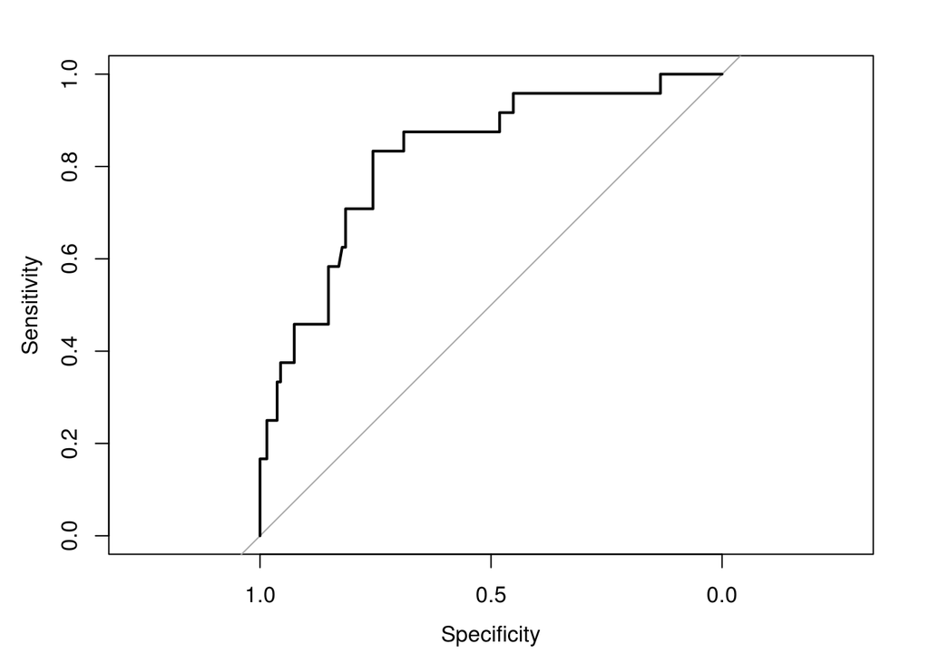

```
## Area under the curve: 0.8224
```

```
## 95% CI: 0.7308-0.9139 (DeLong)
```

AUC is 0.8224.  
95% confident interval for AUC is between 0.7308 and 0.9139 and it does not contain 0.5. So this suggests our model predicts the response variable very well.

### Problem 4

**(a)**

```
## (Intercept)         AGE
##  -5.3094534   0.1109211
```

```
## (Intercept)     exp.AGE
## 0.004944629 1.117306795
```

```
##                    0.5 %    99.5 %
## (Intercept) 0.0001887908 0.0703886
## exp.AGE     1.0557140982 1.1970787
```

```
##
## Call:
## glm(formula = CHD ~ AGE, family = binomial(link = logit), data = CHD)
##
## Deviance Residuals:
##     Min       1Q   Median       3Q      Max
## -1.9718  -0.8456  -0.4576   0.8253   2.2859
##
## Coefficients:
##             Estimate Std. Error z value Pr(>|z|)
## (Intercept) -5.30945    1.13365  -4.683 2.82e-06 ***
## AGE          0.11092    0.02406   4.610 4.02e-06 ***
## ---
## Signif. codes:  0 '***' 0.001 '**' 0.01 '*' 0.05 '.' 0.1 ' ' 1
##
## (Dispersion parameter for binomial family taken to be 1)
##
##     Null deviance: 136.66  on 99  degrees of freedom
## Residual deviance: 107.35  on 98  degrees of freedom
## AIC: 111.35
##
## Number of Fisher Scoring iterations: 4
```

The estimated logistic-regression function : $\ln \frac{\hat{\pi}}{1-\hat{\pi}} = -5.3095 + 0.1109X_{1}$.

**(b)**

```
##         1
## 0.9124646
```

This suggests that a 69 year old has a 0.9125 chance to have CHD.

**(c)**

```
##       AGE
## 0.1109211
```

Since $\beta_{1} = 0.1109 > 0$, the probability of CHD goes up as your age increases.

**(d)**

```
##  exp.AGE
## 1.117307
```

When age increases by 1 year, the odds of CHD will be 1.1173 times that of what it was.

**(e)**

```
##    0.5 %   99.5 %
## 1.055714 1.197079
```

We are 99% confident that when age increases by 1 year, we expect the odds of CHD to be between 1.0557 and 1.1971 times what it was.

### Problem 5

**(a)**

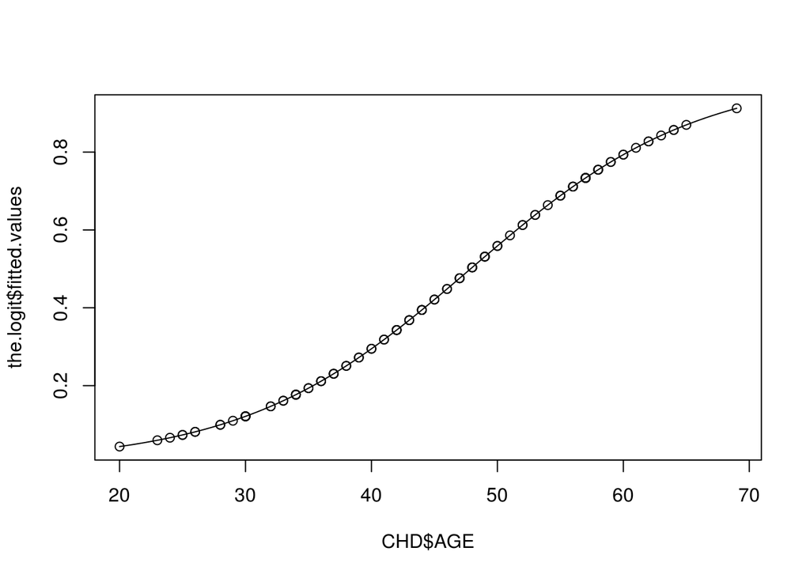

**(b)**

It is difficult to interpret $\beta$’s in logistic regression problem. $e^{\beta_{0}}$ represents the odds of CHD for a 0 year old, $e^{\beta_{0}}$ doesn’t make sense in this case since a patient cannot be 0 year old.

**(c)**

```
##         1
## 0.3943835
```

The reasonable range for patients’ age is from 20 to 69. So it is appropriate to predict a patient aged 44. A 44 year old has a 0.3944 chance to have CHD.

**(d)**

```
## Sensitivity Specificity  Error Rate
##      0.6744      0.7895      0.2600
```

**(e)**

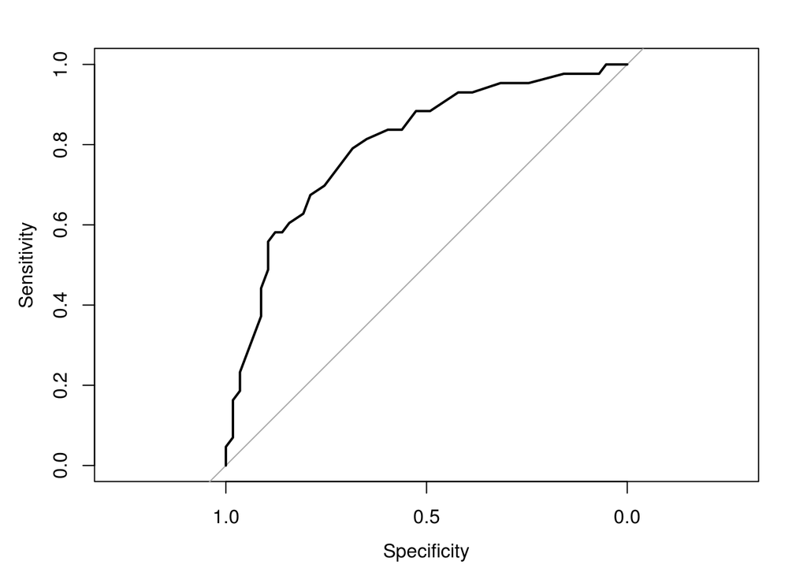

```
## Area under the curve: 0.7999
```

```
## 95% CI: 0.7114-0.8884 (DeLong)
```

AUC is 0.7999.  
95% confident interval for AUC is between 0.7114 and 0.8884 and it does not contain 0.5. So this suggests our model predicts the response variable well.

### Problem 6

**(a)**

True. When $e^{\beta_{1}}$ contains 1, $\beta_{1}$ contains 0. So we can conclude $X_{1}$ has no influence on the odds of trait($Y=1$).

**(b)**

False. $e^{\beta_{1}}$ gives the change in the odds of trait($Y=1$) when $X_{1}$ changes by 1 unit.

**(c)**

False. The variable we are interested in equals $\beta_{0}$ only when all explanatory variables equal 0, but not all $X_{i}$ make sense at 0. Besides, $\beta_{0}$ may not in a reasonable range for $Y$.

**(d)**

True. “fail to reject” means “accept” the null hypothesis $H_{0}: \beta_{1} = 0$, so we can conclude that $X_{1}$ does not effect the odds of trait($Y=1$), thus not effecting probability.

### R Appendix

```r
alcohol <- read.csv("~/STA 101/Homework/HW4/alcohol.csv")
CHD <- read.csv("~/STA 101/Homework/HW4/CHD.csv")
flu <- read.csv("~/STA 101/Homework/HW4/flu.csv")
library(ggplot2)
library(pROC)
library(EnvStats)
the.model = lm(BAC~BrAC, data = alcohol)
LY = boxcox(alcohol$BAC, objective.name = "Log-Likelihood", optimize = TRUE)$lambda
YT = (alcohol$BAC^LY - 1)/LY
t.data = data.frame(Y = YT, X = alcohol$BrAC)
qplot(X, Y, data = t.data) + ggtitle("Transformed BAC vs. BrAC") + xlab("BrAC") + ylab("Transformed BAC")
the.model = lm(Y~X, data = t.data)
Group = rep("Lower", nrow(t.data))
Group[t.data$Y < median(t.data$Y)] = "Upper"
Group = as.factor(Group)
t.data$Group = Group
t.data$ei = the.model$residuals
t.data$yhat = the.model$fitted.values
the.FKtest = fligner.test(t.data$ei, t.data$Group)
the.FKtest
qplot(yhat, ei, data = t.data)+ggtitle("Errors vs. Fitted Values")+xlab("Fitted Values")+ylab("Errors")+geom_hline(yintercept = 0)
LY = boxcox(alcohol$BAC, objective.name = "Log-Likelihood", optimize = TRUE)$lambda
YT = (alcohol$BAC^LY - 1)/LY
LX = boxcox(alcohol$BrAC, objective.name = "Log-Likelihood", optimize = TRUE)$lambda
XT = (alcohol$BrAC^LX - 1)/LX
tt.data = data.frame(Y = YT, X = XT)
qplot(XT, YT, data = tt.data) + ggtitle("Transformed BAC vs. Transformed BrAC") + xlab("Transformed BrAC") + ylab("Transformed BAC")
the.model = lm(Y~X, data = tt.data)
ei = the.model$residuals
tt.data$ei = the.model$residuals
tt.data$yhat = the.model$fitted.values
the.SWtest = shapiro.test(ei)
the.SWtest

Group = rep("Lower", nrow(tt.data))
Group[tt.data$Y < median(tt.data$Y)] = "Upper"
Group = as.factor(Group)
tt.data$Group = Group
the.FKtest = fligner.test(tt.data$ei, tt.data$Group)
the.FKtest

the.logit = glm(shot~age + aware + gender, data = flu, family = binomial(link = logit))
the.betas = the.logit$coefficients
exp.betas = exp(the.betas)
names(exp.betas) = c("(Intercept)", "exp.age", "exp.aware", "exp.genderM")
alpha = 0.1
the.CI = confint(the.logit, level = 1 - alpha)
the.betas
exp.CI = exp(the.CI)
rownames(exp.CI) = c("(Intercept)", "exp.age", "exp.aware", "exp.genderM")
exp.betas
exp.CI
summary(the.logit)
x.star = data.frame(age = 55, aware = 70, gender = "F")
the.predict = predict(the.logit, x.star, type = "response")
the.predict
the.betas[2]
exp.betas[2]
exp.CI[2,]
exp.betas[4]


the.min=min(flu$age)
the.max=max(flu$age)
pi.0 = 0.50
truth = flu$shot
predicted = ifelse(fitted(the.logit)>pi.0, 1, 0)
the.table = table(truth, predicted)
sens = sum(predicted ==1 & truth == 1)/sum(truth == 1)
spec = sum(predicted ==0 & truth == 0)/sum(truth == 0)
error = sum(predicted != truth)/length(predicted)
results = c(sens, spec, error)
names(results) = c("Sensitivity", "Specificity", "Error Rate")
round(results, 4)
the.auc = auc(flu$shot, fitted(the.logit), plot = TRUE)
the.auc
auc.CI = ci(the.auc, level = 1-0.05)
auc.CI
the.logit = glm(CHD~AGE, data = CHD, family = binomial(link = logit))
the.betas = the.logit$coefficients
the.betas
exp.betas = exp(the.betas)
names(exp.betas) = c("(Intercept)", "exp.AGE")
alpha = 0.01
the.CI = confint(the.logit, level = 1 - alpha)
exp.CI = exp(the.CI)
rownames(exp.CI) = c("(Intercept)", "exp.AGE")
exp.betas
exp.CI
summary(the.logit)
x.star = data.frame(AGE = 69)
the.predict = predict(the.logit, x.star, type = "response")
the.predict
the.betas[2]
exp.betas[2]
exp.CI[2,]
the.logit = glm(CHD~AGE, data = CHD, family = binomial(link = logit))
plot(CHD$AGE, the.logit$fitted.values)
curve(predict(the.logit, data.frame(AGE=x), type = "response"), add = TRUE)

the.min=min(CHD$AGE)
the.max=max(CHD$AGE)
x.star = data.frame(AGE = 44)
the.predict = predict(the.logit, x.star, type = "response")
the.predict
pi.0 = 0.50
truth = CHD$CHD
predicted = ifelse(fitted(the.logit)>pi.0, 1, 0)
the.table = table(truth, predicted)
sens = sum(predicted ==1 & truth == 1)/sum(truth == 1)
spec = sum(predicted ==0 & truth == 0)/sum(truth == 0)
error = sum(predicted != truth)/length(predicted)
results = c(sens, spec, error)
names(results) = c("Sensitivity", "Specificity", "Error Rate")
round(results, 4)
the.auc = auc(CHD$CHD, fitted(the.logit), plot = TRUE)
the.auc
auc.CI = ci(the.auc, level = 1-0.05)
auc.CI
```